# annotate_cell_identity

## Annotate cell identity

This pipeline helps annotate cell identity by visualizing marker genes using UMAP or DOT plot, and by performing reference-based annotation based on ScATACtor function.

### Option 1: visualize marker genes

#### Case 1: UMAP visualization

**Inputs** (Required):  
1. **-open_markerUMAP yes**  
2. **-script_dir** (a script directory downloaded from GitHub: Socrates2/utils/input_other_required_scripts_dir)  
3. **-soc_obj** (The *.atac.soc.qs2 object obtained from the [Prepare gene accessibility](http://htmlpreview.github.io/?https://github.com/yanhaidong1/Socrates2/blob/main/vignettes/prepare_gene_accessibility.html) step)  
4. **-marker_fl** (A marker gene file consisting of three tab-separated columns: the first column contains the gene ID, the second column lists the gene symbol, and the third column specifies the cell type represented by the gene. The column headers should be geneID, symbol, and type.)  
5. **-o output_dir** (mkdir output_dir)

**Optional parameters:**  
1. **-lim_val 0.98** (A lim value of visualizing the markers in UMAP； Default: 0.98）

**Outputs:**  
1. opt_UMAP_marker.png

**Running**:

```bash
python Socrates2/utils/annotate_cell_identity.py
-script_dir Socrates2/utils/input_other_required_scripts_dir
-o output_dir
-open_markerUMAP yes
-soc_obj /Path/to/*.atac.soc.qs2
-marker_fl /Path/to/marker.txt
```

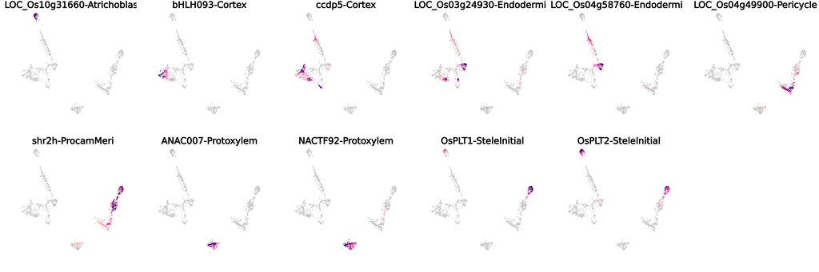

Figure 1: example of UMAP plotting

#### Case 2: Dot plot visualization

**Inputs** (Required):  
1. **-open_dotplot yes**  
2. **-script_dir** (a script directory downloaded from GitHub: Socrates2/utils/input_other_required_scripts_dir)  
3. -soc_obj (The *.atac.soc.qs2 object obtained from the [Prepare gene accessibility](http://htmlpreview.github.io/?https://github.com/yanhaidong1/Socrates2/blob/main/vignettes/prepare_gene_accessibility.html) step)  
4. **-marker_fl** (A marker gene file consisting of three tab-separated columns: the first column contains the gene ID, the second column lists the gene symbol, and the third column specifies the cell type represented by the gene.)  
5. **-o output_dir** (mkdir output_dir)

**Optional parameters:**  
1. **-clustnm LouvainClusters** (Set the cell cluster name within meta file; Default: LouvainClusters.)  
2. **-dotplotwidth 10** (Define the width of output figure of the dotplot. Default: 10.)  
3. **-dotplotheight 10** (Define the height of output figure of the dotplot. Default: 10.)  
4. **-open_only_plot no** (Only plot the marker genes. Once we open this step, we need to make sure we firstly ran the whole step completely to obtain the prepared gene file. Users initiate this argument only if they want to just plot other than build up the prepared file. Default: no.  
5. **-updated_soc_obj *.atac.soc.qs2** (A object file obtained from the firstly running of the whole step.)

**Outputs:**  
1. opt_dotplot_marker.pdf  
2. *.atac.soc.qs2

**Running**:

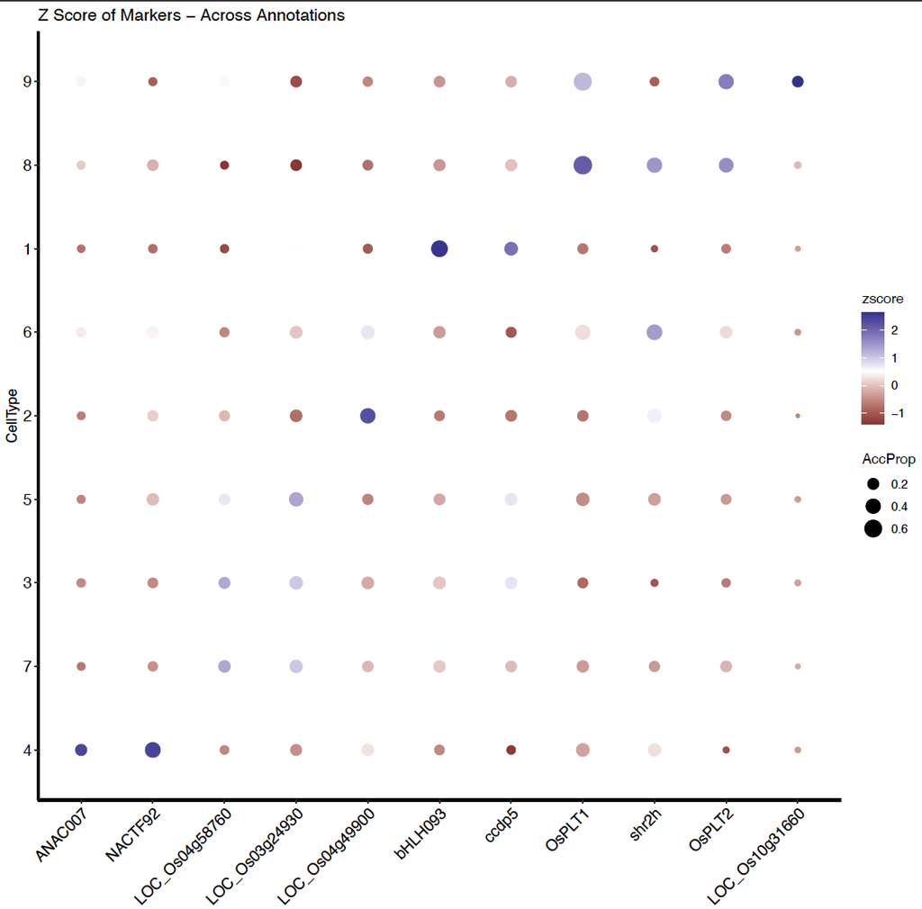

Figure 2: example of marker dot plotting

```bash
python Socrates2/utils/annotate_cell_identity.py
-script_dir Socrates2/utils/input_other_required_scripts_dir
-o output_dir
-open_dotplot yes
-soc_obj /Path/to/*.atac.soc.qs2
-marker_fl /Path/to/marker.txt
```

If users already obtain the file *.atac.soc.qs2, users could run the following script other than build up this file again.

```bash
python Socrates2/utils/annotate_cell_identity.py
-script_dir Socrates2/utils/input_other_required_scripts_dir
-o output_dir
-open_dotplot yes
-open_only_plot yes
-updated_soc_obj /Path/to/*.atac.soc.qs2
-marker_fl /Path/to/marker.txt
```

### Option 2: annotate cell identity using marker genes

This step will automatically annotate cell identity based on chromatin accessibility of each marker gene. The outputs will return a single meta file recording predicted cell identity and also include several PNG image files that visualize the average performance of multiple marker genes within single UMAP file.

Cell type annotation begins with (1) Cell Identity Enrichment, where marker-based Z-scores are calculated by comparing observed chromatin accessibility at marker loci against 1,000 permuted background distributions, generating cell-type-specific enrichment profiles while accounting for marker specificity through entropy-based filtering. These initial predictions are refined through (2) Smoothed Marker Enrichment, where a k=15 nearest-neighbor graph in PCA space facilitates diffusion-based smoothing (3 steps) of enrichment scores, effectively propagating confident local annotations while normalizing probabilities. The pipeline then employs (3) Weighted k-Nearest Neighbors (k=25) to propagate labels from high-confidence cells (top 5% by smoothed scores), with distance-weighted voting and secondary graph smoothing. Finally, (4) Logistic Regression (GLMnet) trains an L1-regularized classifier on genome-wide accessibility patterns from high-confidence cells, using 10-fold cross-validation to optimize feature selection before applying identical diffusion smoothing to predictions.

**Inputs** (Required):  
1. **-open_aggregateAnnot yes**  
2. **-script_dir** (a script directory downloaded from GitHub: Socrates2/utils/input_other_required_scripts_dir)  
3. **-soc_obj** (The *.atac.soc.qs2 object obtained from the [4. Prepare gene accessibility](http://htmlpreview.github.io/?https://github.com/yanhaidong1/Socrates2/blob/main/vignettes/prepare_gene_accessibility.html) step)  
4. **-marker_fl** (A marker gene file consisting of three tab-separated columns: the first column contains the gene ID, the second column lists the gene symbol, and the third column specifies the cell type represented by the gene.)

**Outputs:**  
1. opt_annot.cell_identities.predicted.png; opt_annot.cell_identities.smooth.png; opt_annot.cell_identities.wknn.png  
2. opt_annot.meta.txt  
3. *.atac.soc.qs2

**Running**:

```bash
python Socrates2/utils/annotate_cell_identity.py
-script_dir Socrates2/utils/input_other_required_scripts_dir
-o output_dir
-open_aggregateAnnot yes
-soc_obj /Path/to/*.atac.soc.qs2
-marker_fl /Path/to/marker.txt
```

[figure not shown]

Figure 3: example of prediction using smooth approach

[figure not shown]

Figure 4: example of prediction using wknn approach

[figure not shown]

Figure 5: example of prediction using logistic approach

### Option 3: use the reference-based annotation (ScATACtor)

The reference-based method is to annotate cell identity using a pre-built gene by cell matrix with each cell identity has been annotated. Currently, this pipeline includes rice (nine organs: axillary bud, early seedling, Seedling, leaf, seminal root, crown root, early seed, late seed, panicle), maize etc. Users need to specify which species and organs they want to use to perform the annotation.

**Inputs** (Required):  
1. **-d working_dir** (mkdir working_dir)  
2. **-o output_dir** (mkdir output_dir)  
3. **-script_dir** (a script directory downloaded from GitHub: Socrates2/utils/input_other_required_scripts_dir)  
4. **-train_mtx** (input_reference_mtx can be download from Socrates2)  
5. **-train_meta** (input_reference_cell_meta_fl can be download from Socrates2)  
6. **-unknown_mtx** (The *.atac.soc.qs2 object obtained from the output_dir/open_gene_accessibility_final_dir folder, which is generated during [4. Prepare gene accessibility](http://htmlpreview.github.io/?https://github.com/yanhaidong1/Socrates2/blob/main/vignettes/prepare_gene_accessibility.html))

**Optional parameters:**  
1. **-open_low_mem yes|no** (Users could use the low mem to perform the classification by selecting the top variant features of the training dataset. Default: no)  
2. **-top_ft_num 5000** (Once the low mem open, users could set a top variant ft number. Default: 5000)  
3. **-clust_soc_obj Path/to/clustering_soc_fl** (The *.atac.soc.qs2 object obtained from the [Clustering](http://htmlpreview.github.io/?https://github.com/yanhaidong1/Socrates2/blob/main/vignettes/clustering.html) step)  
4. **-PC_str 50** (Provide a PC number string used for the embeddings. Default: 50)  
5. **-PC_var 0.01** (Only principal components explaining more than 1% of the total variance in the dataset are retained for feature selection and model training. Default: 0.01) 6. **-Rd_type SVD** (Provide a reduction type. Default: SVD)  
7. **-ML_classifier SVM** (Provide a machine learning method. ScATACtor provides Random Forest/RF and Support Vector Machine/SVM. Default: SVM)  
8. **-SVM_kernel rbf** (SVM method provides ‘linear’, ‘poly’, ‘rbf’, ‘sigmoid’, ‘precomputed’ in sklearn. Default: rbf)  
9. **-open_smote yes** (Smote will impute data enabling data balance manner. Default: yes)  
10. **-running_steps All** (Provide running steps to check whether we will run the specific steps. Default: All)  
11. **-open_tunning no** (Specifies whether to enable hyperparameter tuning. Set to yes to perform hyperparameter tuning, or no to skip this step. Default: no)

**Outputs:**  
1. opt_meta_ScATACtor_predicted_cell_identity.txt

**Running**:

```bash
python Socrates2/utils/ScATACtor.py
-d working_dir
-o output_dir
-script_dir Socrates2/utils/input_other_required_scripts_dir
-train_mtx input_reference_mtx
-train_meta input_reference_cell_meta_fl
-unknown_mtx /Path/to/*.atac.soc.qs2
```

### Option 4: validate cell identity using GO enrichment

After completing cell identity annotation, users are encouraged to perform a Gene Ontology (GO) enrichment analysis on the de novo marker genes identified for each cell type, as predicted in [5. Find diff markers](http://htmlpreview.github.io/?https://github.com/yanhaidong1/Socrates2/blob/main/vignettes/find_diff_markers.html). This step gathers a set of de novo marker genes for each cell type and conducts GO enrichment analysis using the TopGO package in R (Alexa and Rahnenführer, 2009).

**Inputs** (Required):  
1. **-open_GO_annot yes**  
2. **-script_dir** (a script directory downloaded from GitHub: Socrates2/utils/input_other_required_scripts_dir)  
3. **-soc_obj** (The *.atac.soc.qs2 object obtained from the [5. Find diff markers](http://htmlpreview.github.io/?https://github.com/yanhaidong1/Socrates2/blob/main/vignettes/find_diff_markers.html) step)  
4. **-gene_GO_fl** (a GO file containing two tab-separated columns without a header. The first column represents the gene ID, while the second column lists the corresponding GO IDs, separated by tabs.)

**Optional parameters:**  
1. **-log2fc_cutoff 0.25** (Set a log2 fold-change cutoff to filter the gene list. Genes with a log2 fold change greater than 0.25 per cell type will be included in the cell type–specific GO enrichment analysis. Default: 0.25)

**Outputs:**  
1. output_denovo_genes_GO_enrich.txt

**Running**:

```bash
python Socrates2/utils/annotate_cell_identity.py
-script_dir Socrates2/utils/input_other_required_scripts_dir
-o output_dir
-open_GO_annot yes
-soc_obj /Path/to/*.atac.soc.qs2
-gene_GO_fl /Path/to/GO.txt
```

### Generate the final UMAP plot with labeled cell identities

After completing cell identity annotation, the user needs to create a cell identity file using the **-cell_annot_fl** option, which specifies the cell type assigned to each cluster. This function then generates a final UMAP plot labeled with the user-defined cell identities. Additionally, two new columns will be added to the metadata file: **cell_identity**, indicating the assigned cell types for each cell; **celltype_color**, specifying the color used for each cell type in the plot.

**Inputs** (Required):  
1. **-open_cell_annot yes**  
2. **-script_dir** (a script directory downloaded from GitHub: Socrates2/utils/input_other_required_scripts_dir)  
3. **-soc_obj** (The *.atac.soc.qs2 object obtained from the [5. Find diff markers](http://htmlpreview.github.io/?https://github.com/yanhaidong1/Socrates2/blob/main/vignettes/find_diff_markers.html) step)  
4. **-cell_annot_fl** (a cell annotation file that assigns a cell type to each cluster. It consists of two tab-separated columns: the first column represents the cluster number, and the second column contains the annotated cell identity.)

**Outputs:**  
1. open_add_cell_annot_identity_final_dir/*.annotated_cell_identity.meta.txt  
2. open_add_cell_annot_identity_final_dir/*.UMAP_annotated_cell_identity.pdf  
3. open_add_cell_annot_identity_final_dir/*.atac.soc.qs2

**Running**:

```bash
python Socrates2/utils/annotate_cell_identity.py
-script_dir Socrates2/utils/input_other_required_scripts_dir
-o output_dir
-open_cell_annot yes
-soc_obj /Path/to/*.atac.soc.qs2
-cell_annot_fl /Path/to/cell_annot_fl.txt
```

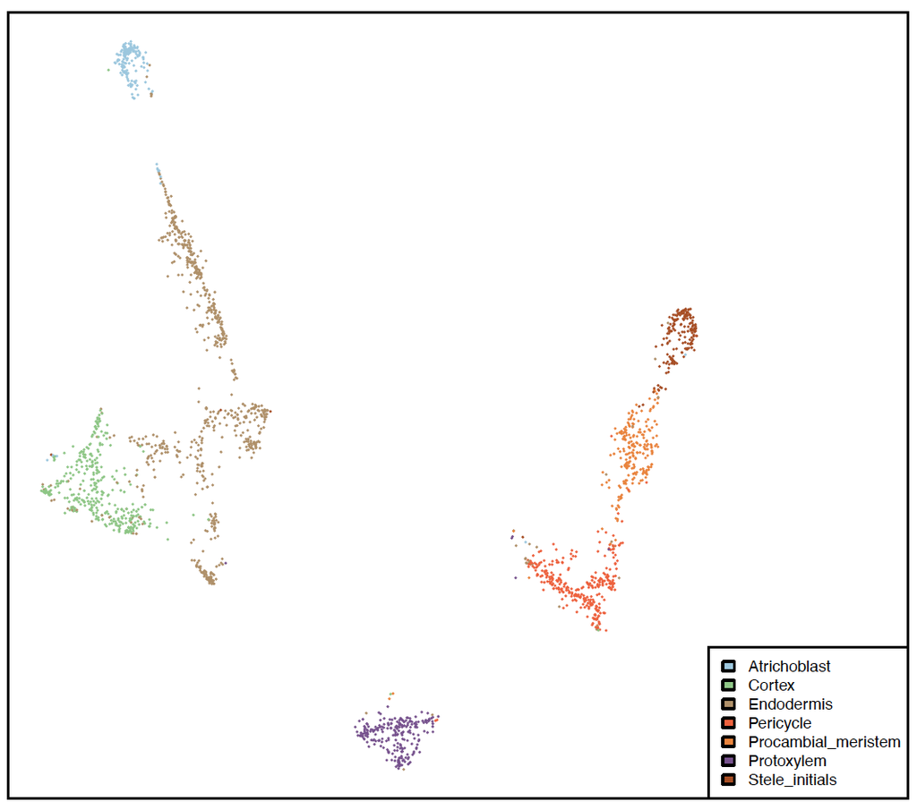

Figure 6: example of final UMAP with annoated cell identities

### Caculate Reads Per Million (CPM) of genes per cell type

After annotating cell identities, **Socrates2** provides an additional option to calculate the **Reads Per Million (CPM)** values of genes for each cell type.

**Inputs** (Required):  
1. **-open_gene_CPM yes**  
2. **-script_dir** (a script directory downloaded from GitHub: Socrates2/utils/input_other_required_scripts_dir)  
3. **-soc_obj** (The *.atac.soc.qs2 object obtained from the [5. Find diff markers](http://htmlpreview.github.io/?https://github.com/yanhaidong1/Socrates2/blob/main/vignettes/find_diff_markers.html) or from the [4. Prepare gene accessibility](http://htmlpreview.github.io/?https://github.com/yanhaidong1/Socrates2/blob/main/vignettes/prepare_gene_accessibility.html) step)  
4. **-meta_fl** The metadata file (`*.annotated_cell_identity.meta.txt`) obtained from the **“Generate the final UMAP plot with labeled cell identities”** step

**Optional parameters:**  
1. **-celltype_col** The column name in the metadata file that indicates cell type identity (default: `cell_identity`)

**Outputs:**  
1. opt_perM_genes_accessibility_cell_identity.txt  
2. opt_rawcounts_gene_accessibility_cell_identity.txt

**Running**:

```bash
python Socrates2/utils/annotate_cell_identity.py
-script_dir Socrates2/utils/input_other_required_scripts_dir
-o output_dir
-open_gene_CPM yes
-soc_obj /Path/to/*.atac.soc.qs2
-meta_fl /Path/to/*.meta.txt
```

### Caculate Reads Per Million (CPM) of genes per cluster

After annotating cell identities, **Socrates2** provides an additional option to calculate the **Reads Per Million (CPM)** values of genes for each cluster.

**Inputs** (Required):  
1. **-open_gene_CPM yes**  
2. **-script_dir** (a script directory downloaded from GitHub: Socrates2/utils/input_other_required_scripts_dir)  
3. **-soc_obj** (The *.atac.soc.qs2 object obtained from the [5. Find diff markers](http://htmlpreview.github.io/?https://github.com/yanhaidong1/Socrates2/blob/main/vignettes/find_diff_markers.html) or from the [4. Prepare gene accessibility](http://htmlpreview.github.io/?https://github.com/yanhaidong1/Socrates2/blob/main/vignettes/prepare_gene_accessibility.html) step)

**Outputs:**  
1. opt_perM_genes_accessibility_cell_identity.txt  
2. opt_rawcounts_gene_accessibility_cell_identity.txt

**Running**:

```bash
python Socrates2/utils/annotate_cell_identity.py
-script_dir Socrates2/utils/input_other_required_scripts_dir
-o output_dir
-open_gene_CPM yes
-soc_obj /Path/to/*.atac.soc.qs2
```